# C-center RSD models

# 1 Preprocessing

## 1.1 Load required packages

```r
library(tidyr)
library(dplyr)
library(stringr)
library(lme4)
library(car)
```

```r
library(visreg)
library(ggplot2)
library(mgcv)
library(itsadug)
```

## 1.2 Read data

```r
df <- readRDS("C:/Users/Jidde/Desktop/analysis/data/modelling_data_RSD.rds")
df <- rename(df, interval_type = condition)
```

## 1.3 Tweak data

```r
# Change order of levels in cluster
df$cluster <- factor(df$cluster, levels = c("sp", "sm", "sx", "spr"))
df <- subset(df, RSD != 0)

# create df without spr
df<- df[! df$cluster == "spr", ]
df <- droplevels(df)
levels(df$cluster)
```

```
## [1] "sp" "sm" "sx"
```

```r
df$group <- recode_factor(df$group, CTRL = "typical")
df$group<- relevel(df$group, ref = "PD")
```

Create ordered factors:

```r
df$group.ord <- as.ordered(df$group)
contrasts(df$group.ord) <- "contr.treatment"
```

Create binary dummy variables:

```r
df$IsTP <- (df$group == "typical")*1
```

Visualize:

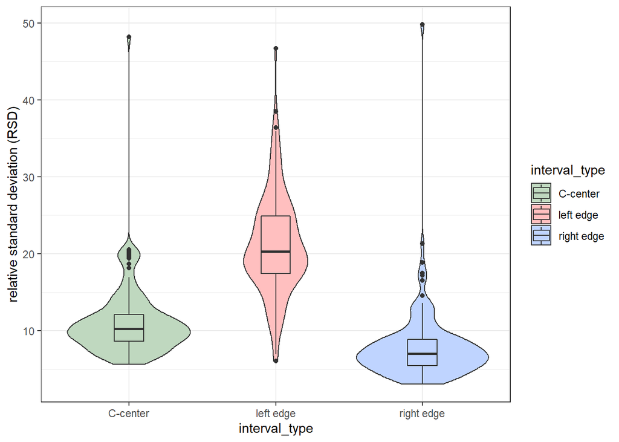

```r
dodge = .5

ggplot(df, aes(x=interval_type, y=RSD, fill=interval_type)) + geom_violin()  + geom_boxplot(width=.2) + labs(y = "relative standard deviation (RSD)")  + scale_fill_manual(values=c("#bfd8bf", "#ffbfbf", "#bfd4ff")) + theme_bw()
```

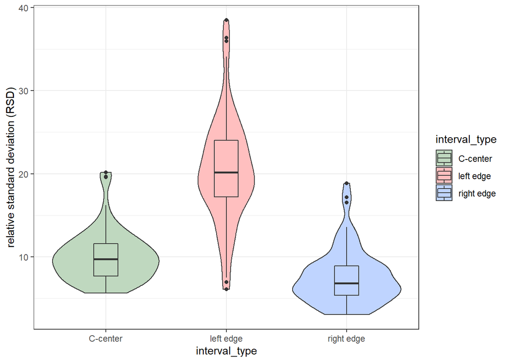

```r
ggplot(df[df$group =="typical",], aes(x=interval_type, y=RSD, fill=interval_type)) + geom_violin()  + geom_boxplot(width=.2) + labs(y = "relative standard deviation (RSD)")  + scale_fill_manual(values=c("#bfd8bf", "#ffbfbf", "#bfd4ff")) + theme_bw()
```

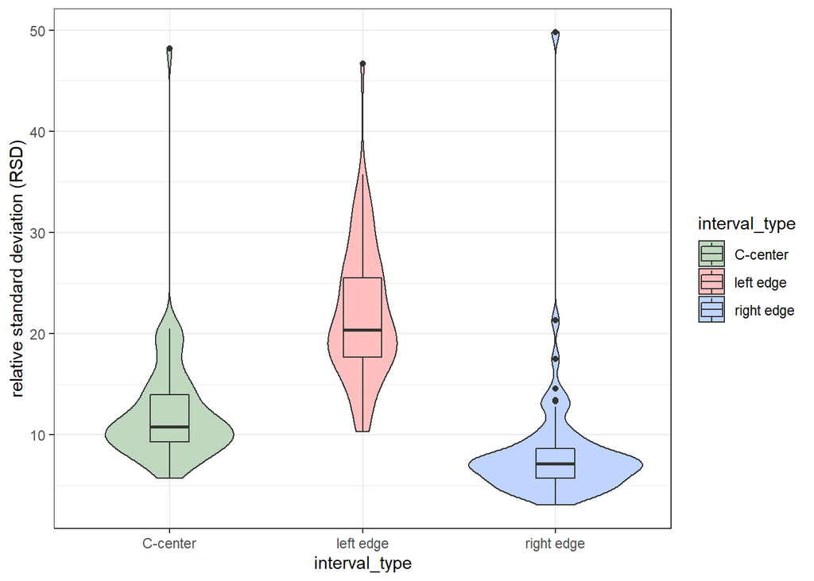

```r
ggplot(df[df$group =="PD",], aes(x=interval_type, y=RSD, fill=interval_type)) + geom_violin()  + geom_boxplot(width=.2) + labs(y = "relative standard deviation (RSD)")  + scale_fill_manual(values=c("#bfd8bf", "#ffbfbf", "#bfd4ff")) + theme_bw()
```

# 2 GAM models for RSD analysis

## 2.1 Hypothesis test

Base model:

```r
summary(mhypo <- bam(RSD ~ s(subj, bs='re'), data=df, method = "ML"))
```

```
##
## Family: gaussian
## Link function: identity
##
## Formula:
## RSD ~ s(subj, bs = "re")
##
## Parametric coefficients:
##             Estimate Std. Error t value Pr(>|t|)
## (Intercept)  13.4472     0.4924   27.31   <2e-16 ***
## ---
## Signif. codes:  0 '***' 0.001 '**' 0.01 '*' 0.05 '.' 0.1 ' ' 1
##
## Approximate significance of smooth terms:
##           edf Ref.df    F p-value
## s(subj) 19.78     46 0.73 0.00433 **
## ---
## Signif. codes:  0 '***' 0.001 '**' 0.01 '*' 0.05 '.' 0.1 ' ' 1
##
## R-sq.(adj) =  0.076   Deviance explained =   12%
## -ML = 1437.3  Scale est. = 57.016    n = 414
```

Add interval_type?

```r
summary(mhypointerval_type <- bam(RSD ~ interval_type + s(subj, bs='re'), data=df, method = "ML"))
```

```
##
## Family: gaussian
## Link function: identity
##
## Formula:
## RSD ~ interval_type + s(subj, bs = "re")
##
## Parametric coefficients:
##                         Estimate Std. Error t value Pr(>|t|)
## (Intercept)              11.1986     0.6131   18.27  < 2e-16 ***
## interval_typeleft edge   10.0950     0.5392   18.72  < 2e-16 ***
## interval_typeright edge  -3.2296     0.5392   -5.99 4.95e-09 ***
## ---
## Signif. codes:  0 '***' 0.001 '**' 0.01 '*' 0.05 '.' 0.1 ' ' 1
##
## Approximate significance of smooth terms:
##           edf Ref.df     F p-value
## s(subj) 37.95     46 4.221  <2e-16 ***
## ---
## Signif. codes:  0 '***' 0.001 '**' 0.01 '*' 0.05 '.' 0.1 ' ' 1
##
## R-sq.(adj) =  0.675   Deviance explained = 70.6%
## -ML =   1248  Scale est. = 20.06     n = 414
```

```r
compareML(mhypo, mhypointerval_type)
```

```
## mhypo: RSD ~ s(subj, bs = "re")
##
## mhypointerval_type: RSD ~ interval_type + s(subj, bs = "re")
```

```
##
## Chi-square test of ML scores
## -----
##                Model    Score Edf Difference    Df  p.value Sig.
## 1              mhypo 1437.341   2
## 2 mhypointerval_type 1248.010   4    189.331 2.000  < 2e-16  ***
##
## AIC difference: 416.96, model mhypointerval_type has lower AIC.
```

Yes.

Random slopes?

```r
summary(mhypoSlopes <- bam(RSD ~ interval_type + s(subj, bs='re') + s(subj, interval_type, bs='re'), data=df, method = "REML"))
```

```
##
## Family: gaussian
## Link function: identity
##
## Formula:
## RSD ~ interval_type + s(subj, bs = "re") + s(subj, interval_type,
##     bs = "re")
##
## Parametric coefficients:
##                         Estimate Std. Error t value Pr(>|t|)
## (Intercept)              11.1989     0.6169  18.153  < 2e-16 ***
## interval_typeleft edge   10.0950     0.5391  18.727  < 2e-16 ***
## interval_typeright edge  -3.2296     0.5391  -5.991 4.92e-09 ***
## ---
## Signif. codes:  0 '***' 0.001 '**' 0.01 '*' 0.05 '.' 0.1 ' ' 1
##
## Approximate significance of smooth terms:
##                             edf Ref.df     F p-value
## s(subj)               38.087129     46 4.241  <2e-16 ***
## s(subj,interval_type)  0.008569    138 0.000   0.658
## ---
## Signif. codes:  0 '***' 0.001 '**' 0.01 '*' 0.05 '.' 0.1 ' ' 1
##
## R-sq.(adj) =  0.675   Deviance explained = 70.7%
## -REML = 1247.3  Scale est. = 20.049    n = 414
```

No.

Scaled t?

```r
summary(mhypo2_scat <- bam(RSD ~ interval_type + s(subj, bs='re'), data=df, method ="fREML", family = "scat", discrete = T))
```

```
##
## Family: Scaled t(3,2.493)
## Link function: identity
##
## Formula:
## RSD ~ interval_type + s(subj, bs = "re")
##
## Parametric coefficients:
##                         Estimate Std. Error t value Pr(>|t|)
## (Intercept)              10.5747     0.3790  27.902   <2e-16 ***
## interval_typeleft edge   10.1065     0.3908  25.864   <2e-16 ***
## interval_typeright edge  -3.2591     0.3511  -9.282   <2e-16 ***
## ---
## Signif. codes:  0 '***' 0.001 '**' 0.01 '*' 0.05 '.' 0.1 ' ' 1
##
## Approximate significance of smooth terms:
##           edf Ref.df     F p-value
## s(subj) 34.45     46 3.229  <2e-16 ***
## ---
## Signif. codes:  0 '***' 0.001 '**' 0.01 '*' 0.05 '.' 0.1 ' ' 1
##
## R-sq.(adj) =  0.597   Deviance explained =   57%
## fREML = 772.94  Scale est. = 1         n = 414
```

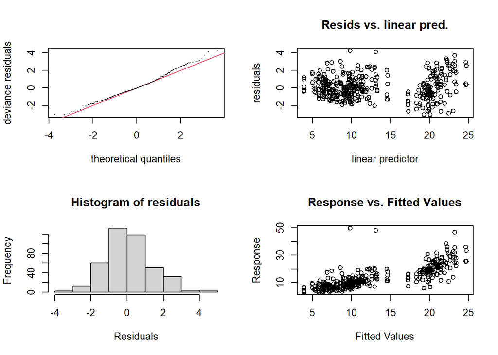

```
##
## Method: fREML   Optimizer: perf chol
## $grad
## [1] 1.320071e-06
##
## $hess
##          [,1]
## [1,] 11.43837
##
## Model rank =  50 / 50
##
## Basis dimension (k) checking results. Low p-value (k-index<1) may
## indicate that k is too low, especially if edf is close to k'.
##
##           k'  edf k-index p-value
## s(subj) 47.0 34.4      NA      NA
```

```r
gam.check(mhypo2_scat)
```

Log?

```r
summary(mhypo2_log <- bam(RSD ~ interval_type + s(subj, bs='re'), data=df, family =Gamma(link=log)))
```

```
##
## Family: Gamma
## Link function: log
##
## Formula:
## RSD ~ interval_type + s(subj, bs = "re")
##
## Parametric coefficients:
##                         Estimate Std. Error t value Pr(>|t|)
## (Intercept)              2.38310    0.04157  57.325   <2e-16 ***
## interval_typeleft edge   0.65697    0.03822  17.188   <2e-16 ***
## interval_typeright edge -0.34853    0.03822  -9.118   <2e-16 ***
## ---
## Signif. codes:  0 '***' 0.001 '**' 0.01 '*' 0.05 '.' 0.1 ' ' 1
##
## Approximate significance of smooth terms:
##           edf Ref.df    F p-value
## s(subj) 36.91     46 3.74  <2e-16 ***
## ---
## Signif. codes:  0 '***' 0.001 '**' 0.01 '*' 0.05 '.' 0.1 ' ' 1
##
## R-sq.(adj) =  0.668   Deviance explained = 72.3%
## fREML = 156.41  Scale est. = 0.10081   n = 414
```

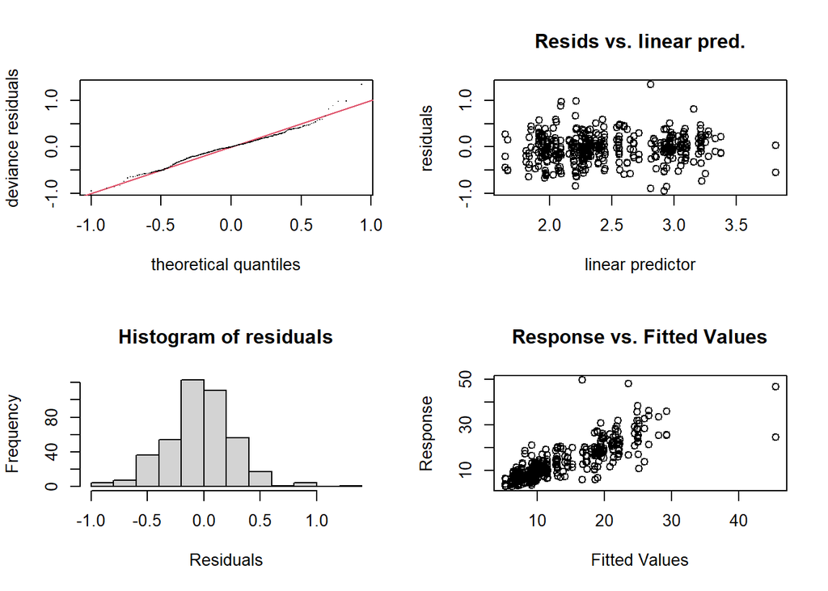

```
##
## Method: fREML   Optimizer: perf newton
## full convergence after 5 iterations.
## Gradient range [-7.167955e-11,1.686118e-11]
## (score 156.4095 & scale 0.1008068).
## Hessian positive definite, eigenvalue range [12.23365,207.2622].
## Model rank =  50 / 50
##
## Basis dimension (k) checking results. Low p-value (k-index<1) may
## indicate that k is too low, especially if edf is close to k'.
##
##           k'  edf k-index p-value
## s(subj) 47.0 36.9      NA      NA
```

```r
gam.check(mhypo2_log)
```

Looks best.

Model criticism, trimming:

```r
df2 <- df[abs(scale(resid(mhypo2_log))) < 2.5, ] # trim model
(1 - (nrow(df2))/nrow(df)) * 100
```

```
## [1] 2.173913
```

2.2% removed.

Refit:

```r
summary(mhypo2_log_trim <- bam(RSD ~ interval_type +s(subj, bs='re'), data=df2, family =Gamma(link=log)))
```

```
##
## Family: Gamma
## Link function: log
##
## Formula:
## RSD ~ interval_type + s(subj, bs = "re")
##
## Parametric coefficients:
##                         Estimate Std. Error t value Pr(>|t|)
## (Intercept)              2.36883    0.03467   68.32   <2e-16 ***
## interval_typeleft edge   0.67882    0.03241   20.95   <2e-16 ***
## interval_typeright edge -0.38460    0.03267  -11.77   <2e-16 ***
## ---
## Signif. codes:  0 '***' 0.001 '**' 0.01 '*' 0.05 '.' 0.1 ' ' 1
##
## Approximate significance of smooth terms:
##           edf Ref.df    F p-value
## s(subj) 36.31     46 3.73  <2e-16 ***
## ---
## Signif. codes:  0 '***' 0.001 '**' 0.01 '*' 0.05 '.' 0.1 ' ' 1
##
## R-sq.(adj) =  0.757   Deviance explained = 77.8%
## fREML = 83.812  Scale est. = 0.071589  n = 405
```

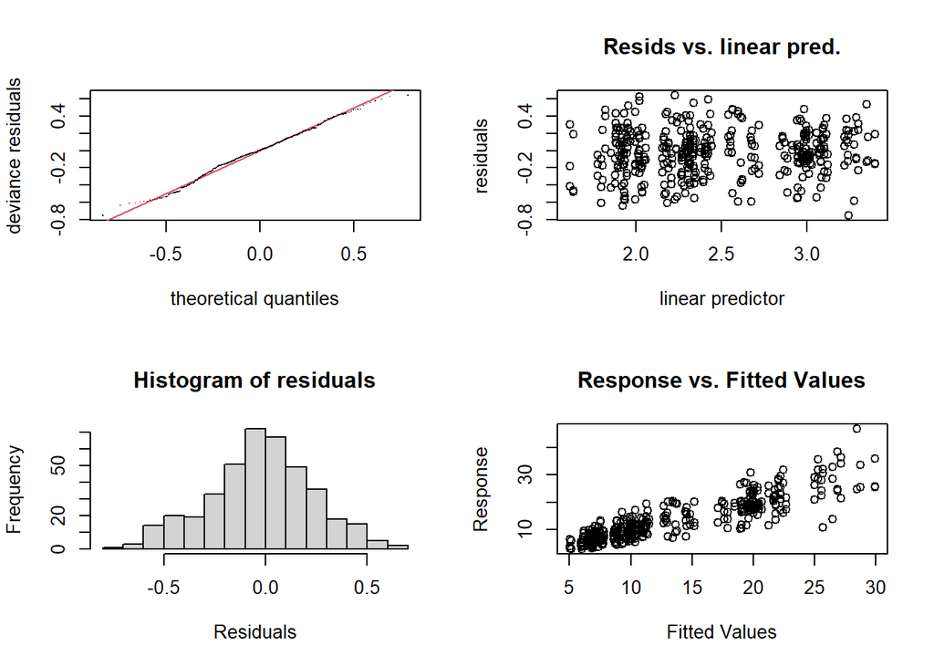

```
##
## Method: fREML   Optimizer: perf newton
## full convergence after 5 iterations.
## Gradient range [-1.156764e-10,2.764722e-11]
## (score 83.81177 & scale 0.07158948).
## Hessian positive definite, eigenvalue range [12.17236,202.7453].
## Model rank =  50 / 50
##
## Basis dimension (k) checking results. Low p-value (k-index<1) may
## indicate that k is too low, especially if edf is close to k'.
##
##           k'  edf k-index p-value
## s(subj) 47.0 36.3      NA      NA
```

```r
gam.check(mhypo2_log_trim)
```

Plot:

```
## Summary:
##  * interval_type : factor; set to the value(s): C-center, left edge, right edge.
##  * subj : factor; set to the value(s): CTRL01. (Might be canceled as random effect, check below.)
##  * NOTE : The following random effects columns are canceled: s(subj)
##
```

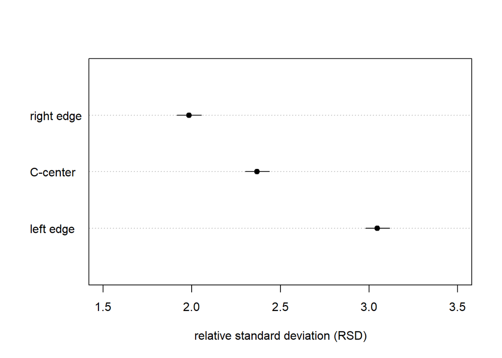

```r
plot_parametric(mhypo2_log_trim, pred=list(interval_type = c("left edge", "C-center", "right edge")), main = "", xlab = "relative standard deviation (RSD)", xlim=c(1.5,3.5))
```

## 2.2 Exploratory analysis

Add group?

```r
summary(mhypo2_log_trim_ML <- bam(RSD ~ interval_type + s(subj, bs='re'), data=df, family =Gamma(link=log), method = "ML"))
```

```
##
## Family: Gamma
## Link function: log
##
## Formula:
## RSD ~ interval_type + s(subj, bs = "re")
##
## Parametric coefficients:
##                         Estimate Std. Error t value Pr(>|t|)
## (Intercept)              2.38313    0.04134   57.64   <2e-16 ***
## interval_typeleft edge   0.65693    0.03826   17.17   <2e-16 ***
## interval_typeright edge -0.34851    0.03826   -9.11   <2e-16 ***
## ---
## Signif. codes:  0 '***' 0.001 '**' 0.01 '*' 0.05 '.' 0.1 ' ' 1
##
## Approximate significance of smooth terms:
##           edf Ref.df     F p-value
## s(subj) 36.75     46 3.717  <2e-16 ***
## ---
## Signif. codes:  0 '***' 0.001 '**' 0.01 '*' 0.05 '.' 0.1 ' ' 1
##
## R-sq.(adj) =  0.668   Deviance explained = 72.3%
## -ML = 149.39  Scale est. = 0.10099   n = 414
```

```r
summary(mgroup <- bam(RSD ~ group + interval_type + s(subj, bs='re'), data=df, family =Gamma(link=log), method = "ML"))
```

```
##
## Family: Gamma
## Link function: log
##
## Formula:
## RSD ~ group + interval_type + s(subj, bs = "re")
##
## Parametric coefficients:
##                         Estimate Std. Error t value Pr(>|t|)
## (Intercept)              2.44221    0.05340  45.736   <2e-16 ***
## grouptypical            -0.11577    0.06782  -1.707   0.0886 .
## interval_typeleft edge   0.65738    0.03828  17.174   <2e-16 ***
## interval_typeright edge -0.34772    0.03828  -9.084   <2e-16 ***
## ---
## Signif. codes:  0 '***' 0.001 '**' 0.01 '*' 0.05 '.' 0.1 ' ' 1
##
## Approximate significance of smooth terms:
##           edf Ref.df     F p-value
## s(subj) 35.37     45 3.521  <2e-16 ***
## ---
## Signif. codes:  0 '***' 0.001 '**' 0.01 '*' 0.05 '.' 0.1 ' ' 1
##
## R-sq.(adj) =  0.667   Deviance explained = 72.2%
## -ML = 148.02  Scale est. = 0.1011    n = 414
```

```r
compareML(mhypo2_log_trim_ML, mgroup)
```

```
## mhypo2_log_trim_ML: RSD ~ interval_type + s(subj, bs = "re")
##
## mgroup: RSD ~ group + interval_type + s(subj, bs = "re")
```

```
##
## Chi-square test of ML scores
## -----
##                Model    Score Edf Difference    Df p.value Sig.
## 1 mhypo2_log_trim_ML 149.3860   4
## 2             mgroup 148.0218   5      1.364 1.000   0.099
##
## AIC difference: -0.06, model mhypo2_log_trim_ML has lower AIC.
```

No.

Add group in interaction with interval type?

```r
summary(mgroupinter <- bam(RSD ~ group*interval_type + s(subj, bs='re'), data=df, family =Gamma(link=log), method = "ML"))
```

```
##
## Family: Gamma
## Link function: log
##
## Formula:
## RSD ~ group * interval_type + s(subj, bs = "re")
##
## Parametric coefficients:
##                                      Estimate Std. Error t value Pr(>|t|)
## (Intercept)                           2.47931    0.05826  42.555  < 2e-16 ***
## grouptypical                         -0.18817    0.08110  -2.320   0.0209 *
## interval_typeleft edge                0.60752    0.05536  10.975  < 2e-16 ***
## interval_typeright edge              -0.41016    0.05536  -7.409 8.59e-13 ***
## grouptypical:interval_typeleft edge   0.09676    0.07664   1.263   0.2075
## grouptypical:interval_typeright edge  0.12052    0.07664   1.573   0.1167
## ---
## Signif. codes:  0 '***' 0.001 '**' 0.01 '*' 0.05 '.' 0.1 ' ' 1
##
## Approximate significance of smooth terms:
##          edf Ref.df     F p-value
## s(subj) 35.4     45 3.518  <2e-16 ***
## ---
## Signif. codes:  0 '***' 0.001 '**' 0.01 '*' 0.05 '.' 0.1 ' ' 1
##
## R-sq.(adj) =  0.669   Deviance explained = 72.4%
## -ML = 147.07  Scale est. = 0.10113   n = 414
```

```r
compareML(mhypo2_log_trim_ML, mgroupinter)
```

```
## mhypo2_log_trim_ML: RSD ~ interval_type + s(subj, bs = "re")
##
## mgroupinter: RSD ~ group * interval_type + s(subj, bs = "re")
```

```
##
## Chi-square test of ML scores
## -----
##                Model    Score Edf Difference    Df p.value Sig.
## 1 mhypo2_log_trim_ML 149.3860   4
## 2        mgroupinter 147.0708   7      2.315 3.000   0.201
##
## AIC difference: -1.35, model mhypo2_log_trim_ML has lower AIC.
```

No.

Adding cluster as fixed effect:

```r
summary(ex1 <- bam(RSD ~ s(subj, bs='re') + cluster + interval_type, data=df, family =Gamma(link=log), method = "ML"))
```

```
##
## Family: Gamma
## Link function: log
##
## Formula:
## RSD ~ s(subj, bs = "re") + cluster + interval_type
##
## Parametric coefficients:
##                         Estimate Std. Error t value Pr(>|t|)
## (Intercept)              2.30433    0.04595  50.151  < 2e-16 ***
## clustersm                0.12601    0.03689   3.416 0.000707 ***
## clustersx                0.11117    0.03774   2.946 0.003427 **
## interval_typeleft edge   0.65759    0.03729  17.634  < 2e-16 ***
## interval_typeright edge -0.35231    0.03729  -9.448  < 2e-16 ***
## ---
## Signif. codes:  0 '***' 0.001 '**' 0.01 '*' 0.05 '.' 0.1 ' ' 1
##
## Approximate significance of smooth terms:
##           edf Ref.df     F p-value
## s(subj) 37.05     46 3.859  <2e-16 ***
## ---
## Signif. codes:  0 '***' 0.001 '**' 0.01 '*' 0.05 '.' 0.1 ' ' 1
##
## R-sq.(adj) =  0.682   Deviance explained = 73.2%
## -ML = 138.49  Scale est. = 0.095951  n = 414
```

```r
compareML(mhypo2_log_trim_ML, ex1)
```

```
## mhypo2_log_trim_ML: RSD ~ interval_type + s(subj, bs = "re")
##
## ex1: RSD ~ s(subj, bs = "re") + cluster + interval_type
```

```
##
## Chi-square test of ML scores
## -----
##                Model    Score Edf Difference    Df   p.value Sig.
## 1 mhypo2_log_trim_ML 149.3860   4
## 2                ex1 138.4877   6     10.898 2.000 1.849e-05  ***
##
## AIC difference: 11.45, model ex1 has lower AIC.
```

Sign. improvement.

Adding slopes:

```r
summary(ex2 <- bam(RSD ~   interval_type + cluster + s(subj, bs='re') +  s(subj, cluster, bs='re'), data=df, family =Gamma(link=log)))
```

```
##
## Family: Gamma
## Link function: log
##
## Formula:
## RSD ~ interval_type + cluster + s(subj, bs = "re") + s(subj,
##     cluster, bs = "re")
##
## Parametric coefficients:
##                         Estimate Std. Error t value Pr(>|t|)
## (Intercept)              2.29710    0.04585  50.096   <2e-16 ***
## interval_typeleft edge   0.66010    0.03355  19.673   <2e-16 ***
## interval_typeright edge -0.35632    0.03355 -10.619   <2e-16 ***
## clustersm                0.12369    0.04524   2.734   0.0066 **
## clustersx                0.10083    0.04623   2.181   0.0299 *
## ---
## Signif. codes:  0 '***' 0.001 '**' 0.01 '*' 0.05 '.' 0.1 ' ' 1
##
## Approximate significance of smooth terms:
##                   edf Ref.df     F  p-value
## s(subj)         30.70     46 4.956  < 2e-16 ***
## s(subj,cluster) 48.15    135 0.830 0.000699 ***
## ---
## Signif. codes:  0 '***' 0.001 '**' 0.01 '*' 0.05 '.' 0.1 ' ' 1
##
## R-sq.(adj) =  0.743   Deviance explained = 79.9%
## fREML = 136.76  Scale est. = 0.077682  n = 414
```

Yes.

Check once more if we need slopes for interval_type

```r
summary(ex_cond_slopes <- bam(RSD ~ interval_type + cluster + s(subj, bs='re') +  s(subj, interval_type, bs='re') +  s(subj, cluster, bs='re'), data=df, family =Gamma(link=log)))
```

```
##
## Family: Gamma
## Link function: log
##
## Formula:
## RSD ~ interval_type + cluster + s(subj, bs = "re") + s(subj,
##     interval_type, bs = "re") + s(subj, cluster, bs = "re")
##
## Parametric coefficients:
##                         Estimate Std. Error t value Pr(>|t|)
## (Intercept)              2.29449    0.04685  48.972   <2e-16 ***
## interval_typeleft edge   0.65880    0.03814  17.272   <2e-16 ***
## interval_typeright edge -0.36283    0.03814  -9.513   <2e-16 ***
## clustersm                0.12059    0.04486   2.688   0.0076 **
## clustersx                0.09769    0.04584   2.131   0.0339 *
## ---
## Signif. codes:  0 '***' 0.001 '**' 0.01 '*' 0.05 '.' 0.1 ' ' 1
##
## Approximate significance of smooth terms:
##                         edf Ref.df     F  p-value
## s(subj)               27.37     46 6.061 2.13e-05 ***
## s(subj,interval_type) 33.78    138 0.419 0.019874 *
## s(subj,cluster)       54.83    135 1.140 0.000271 ***
## ---
## Signif. codes:  0 '***' 0.001 '**' 0.01 '*' 0.05 '.' 0.1 ' ' 1
##
## R-sq.(adj) =  0.775   Deviance explained = 84.5%
## fREML = 134.34  Scale est. = 0.067166  n = 414
```

We do.

Adding interval_type*cluster interaction:

```r
summary(ex3 <- bam(RSD ~   interval_type + cluster + s(subj, bs='re') + s(subj, interval_type, bs='re') + s(subj, cluster, bs='re'), data=df, family =Gamma(link=log), method = "ML"))
```

```
##
## Family: Gamma
## Link function: log
##
## Formula:
## RSD ~ interval_type + cluster + s(subj, bs = "re") + s(subj,
##     interval_type, bs = "re") + s(subj, cluster, bs = "re")
##
## Parametric coefficients:
##                         Estimate Std. Error t value Pr(>|t|)
## (Intercept)              2.29465    0.04656  49.286  < 2e-16 ***
## interval_typeleft edge   0.65881    0.03788  17.394  < 2e-16 ***
## interval_typeright edge -0.36252    0.03788  -9.571  < 2e-16 ***
## clustersm                0.12079    0.04458   2.710  0.00712 **
## clustersx                0.09795    0.04555   2.150  0.03233 *
## ---
## Signif. codes:  0 '***' 0.001 '**' 0.01 '*' 0.05 '.' 0.1 ' ' 1
##
## Approximate significance of smooth terms:
##                         edf Ref.df     F  p-value
## s(subj)               27.56     46 5.934  1.2e-05 ***
## s(subj,interval_type) 32.17    138 0.391 0.020072 *
## s(subj,cluster)       53.73    135 1.097 0.000224 ***
## ---
## Signif. codes:  0 '***' 0.001 '**' 0.01 '*' 0.05 '.' 0.1 ' ' 1
##
## R-sq.(adj) =  0.774   Deviance explained = 84.2%
## -ML = 122.59  Scale est. = 0.067789  n = 414
```

```r
summary(ex4 <- bam(RSD ~   interval_type + interval_type*cluster + s(subj, bs='re') +  s(subj, interval_type, bs='re') +  s(subj, cluster, bs='re'), data=df, family =Gamma(link=log), method = "ML"))
```

```
##
## Family: Gamma
## Link function: log
##
## Formula:
## RSD ~ interval_type + interval_type * cluster + s(subj, bs = "re") +
##     s(subj, interval_type, bs = "re") + s(subj, cluster, bs = "re")
##
## Parametric coefficients:
##                                   Estimate Std. Error t value Pr(>|t|)
## (Intercept)                        2.31692    0.05243  44.191  < 2e-16 ***
## interval_typeleft edge             0.68707    0.05581  12.312  < 2e-16 ***
## interval_typeright edge           -0.46893    0.05581  -8.403 2.49e-15 ***
## clustersm                          0.07214    0.06041   1.194  0.23346
## clustersx                          0.07189    0.06168   1.166  0.24478
## interval_typeleft edge:clustersm   0.04875    0.06991   0.697  0.48622
## interval_typeright edge:clustersm  0.09434    0.06991   1.349  0.17835
## interval_typeleft edge:clustersx  -0.15319    0.07130  -2.148  0.03257 *
## interval_typeright edge:clustersx  0.21832    0.07130   3.062  0.00242 **
## ---
## Signif. codes:  0 '***' 0.001 '**' 0.01 '*' 0.05 '.' 0.1 ' ' 1
##
## Approximate significance of smooth terms:
##                         edf Ref.df     F  p-value
## s(subj)               25.88     46 7.755 0.000138 ***
## s(subj,interval_type) 45.86    138 0.742 0.003751 **
## s(subj,cluster)       62.19    135 1.640 0.000133 ***
## ---
## Signif. codes:  0 '***' 0.001 '**' 0.01 '*' 0.05 '.' 0.1 ' ' 1
##
## R-sq.(adj) =  0.802   Deviance explained = 87.7%
## -ML = 107.92  Scale est. = 0.057434  n = 414
```

```r
compareML(ex3,ex4)
```

```
## ex3: RSD ~ interval_type + cluster + s(subj, bs = "re") + s(subj,
##     interval_type, bs = "re") + s(subj, cluster, bs = "re")
##
## ex4: RSD ~ interval_type + interval_type * cluster + s(subj, bs = "re") +
##     s(subj, interval_type, bs = "re") + s(subj, cluster, bs = "re")
```

```
##
## Chi-square test of ML scores
## -----
##   Model    Score Edf Difference    Df   p.value Sig.
## 1   ex3 122.5880   8
## 2   ex4 107.9159  12     14.672 4.000 6.655e-06  ***
##
## AIC difference: 46.69, model ex4 has lower AIC.
```

Sign. improvement.

Add speech rate

```r
summary(ex5 <- bam(RSD ~ interval_type + interval_type*cluster + s(mean.sr) + s(subj, bs='re') +  s(subj, interval_type, bs='re')+  s(subj, cluster, bs='re'), data=df, family =Gamma(link=log), method = "ML"))
```

```
##
## Family: Gamma
## Link function: log
##
## Formula:
## RSD ~ interval_type + interval_type * cluster + s(mean.sr) +
##     s(subj, bs = "re") + s(subj, interval_type, bs = "re") +
##     s(subj, cluster, bs = "re")
##
## Parametric coefficients:
##                                   Estimate Std. Error t value Pr(>|t|)
## (Intercept)                        2.31794    0.05157  44.945  < 2e-16 ***
## interval_typeleft edge             0.68710    0.05576  12.322  < 2e-16 ***
## interval_typeright edge           -0.46872    0.05576  -8.406 2.45e-15 ***
## clustersm                          0.06784    0.06086   1.115  0.26603
## clustersx                          0.07260    0.06207   1.170  0.24323
## interval_typeleft edge:clustersm   0.04908    0.06984   0.703  0.48281
## interval_typeright edge:clustersm  0.09437    0.06984   1.351  0.17776
## interval_typeleft edge:clustersx  -0.15386    0.07123  -2.160  0.03165 *
## interval_typeright edge:clustersx  0.21873    0.07123   3.071  0.00235 **
## ---
## Signif. codes:  0 '***' 0.001 '**' 0.01 '*' 0.05 '.' 0.1 ' ' 1
##
## Approximate significance of smooth terms:
##                         edf Ref.df     F  p-value
## s(mean.sr)             1.00      1 3.068 0.080963 .
## s(subj)               22.76     46 5.883 0.000875 ***
## s(subj,interval_type) 46.34    138 0.748 0.002622 **
## s(subj,cluster)       64.34    134 1.737 4.62e-05 ***
## ---
## Signif. codes:  0 '***' 0.001 '**' 0.01 '*' 0.05 '.' 0.1 ' ' 1
##
## R-sq.(adj) =  0.803   Deviance explained = 87.7%
## -ML = 106.21  Scale est. = 0.057316  n = 414
```

```r
compareML(ex4, ex5)
```

```
## ex4: RSD ~ interval_type + interval_type * cluster + s(subj, bs = "re") +
##     s(subj, interval_type, bs = "re") + s(subj, cluster, bs = "re")
##
## ex5: RSD ~ interval_type + interval_type * cluster + s(mean.sr) +
##     s(subj, bs = "re") + s(subj, interval_type, bs = "re") +
##     s(subj, cluster, bs = "re")
```

```
##
## Chi-square test of ML scores
## -----
##   Model    Score Edf Difference    Df p.value Sig.
## 1   ex4 107.9159  12
## 2   ex5 106.2095  14      1.706 2.000   0.182
##
## AIC difference: -0.56, model ex4 has lower AIC.
```

No improv.

Add speech rate separate for group?

```r
summary(ex6 <- bam(RSD ~   group.ord + interval_type + interval_type*cluster + s(mean.sr, by = IsTP) + s(subj, bs='re') +  s(subj, interval_type, bs='re') + s(subj, cluster, bs='re'), data=df, family =Gamma(link=log)))
```

```
##
## Family: Gamma
## Link function: log
##
## Formula:
## RSD ~ group.ord + interval_type + interval_type * cluster + s(mean.sr,
##     by = IsTP) + s(subj, bs = "re") + s(subj, interval_type,
##     bs = "re") + s(subj, cluster, bs = "re")
##
## Parametric coefficients:
##                                   Estimate Std. Error t value Pr(>|t|)
## (Intercept)                        2.37220    0.06019  39.413  < 2e-16 ***
## group.ordtypical                   0.01173    0.21544   0.054  0.95663
## interval_typeleft edge             0.68716    0.05587  12.299  < 2e-16 ***
## interval_typeright edge           -0.46834    0.05587  -8.382 2.83e-15 ***
## clustersm                          0.06387    0.06067   1.053  0.29340
## clustersx                          0.07198    0.06175   1.166  0.24473
## interval_typeleft edge:clustersm   0.04875    0.07011   0.695  0.48742
## interval_typeright edge:clustersm  0.09430    0.07011   1.345  0.17973
## interval_typeleft edge:clustersx  -0.15335    0.07150  -2.145  0.03286 *
## interval_typeright edge:clustersx  0.21835    0.07150   3.054  0.00248 **
## ---
## Signif. codes:  0 '***' 0.001 '**' 0.01 '*' 0.05 '.' 0.1 ' ' 1
##
## Approximate significance of smooth terms:
##                          edf  Ref.df     F  p-value
## s(mean.sr):IsTP        2.068   2.197 0.753  0.31761
## s(subj)               22.197  45.000 5.089  0.00269 **
## s(subj,interval_type) 45.711 137.000 0.706  0.00340 **
## s(subj,cluster)       62.165 133.000 1.542 7.06e-05 ***
## ---
## Signif. codes:  0 '***' 0.001 '**' 0.01 '*' 0.05 '.' 0.1 ' ' 1
##
## Rank: 348/349
## R-sq.(adj) =  0.803   Deviance explained = 87.6%
## fREML = 129.12  Scale est. = 0.057759  n = 414
```

No.

Add gender

```r
summary(ex7 <- bam(RSD ~   interval_type + interval_type*cluster + gender + s(subj, bs='re')+  s(subj, interval_type, bs='re') +  s(subj, cluster, bs='re'), data=df, family =Gamma(link=log), method = "ML"))
```

```
##
## Family: Gamma
## Link function: log
##
## Formula:
## RSD ~ interval_type + interval_type * cluster + gender + s(subj,
##     bs = "re") + s(subj, interval_type, bs = "re") + s(subj,
##     cluster, bs = "re")
##
## Parametric coefficients:
##                                   Estimate Std. Error t value Pr(>|t|)
## (Intercept)                        2.33098    0.07617  30.602  < 2e-16 ***
## interval_typeleft edge             0.68708    0.05582  12.308  < 2e-16 ***
## interval_typeright edge           -0.46889    0.05582  -8.400 2.54e-15 ***
## clustersm                          0.07218    0.06044   1.194  0.23343
## clustersx                          0.07202    0.06171   1.167  0.24421
## genderM                           -0.01892    0.07420  -0.255  0.79891
## interval_typeleft edge:clustersm   0.04876    0.06994   0.697  0.48634
## interval_typeright edge:clustersm  0.09432    0.06994   1.349  0.17858
## interval_typeleft edge:clustersx  -0.15329    0.07133  -2.149  0.03251 *
## interval_typeright edge:clustersx  0.21819    0.07133   3.059  0.00244 **
## ---
## Signif. codes:  0 '***' 0.001 '**' 0.01 '*' 0.05 '.' 0.1 ' ' 1
##
## Approximate significance of smooth terms:
##                         edf Ref.df     F  p-value
## s(subj)               25.27     45 7.857 0.000111 ***
## s(subj,interval_type) 45.74    137 0.745 0.003255 **
## s(subj,cluster)       62.04    134 1.653 0.000100 ***
## ---
## Signif. codes:  0 '***' 0.001 '**' 0.01 '*' 0.05 '.' 0.1 ' ' 1
##
## R-sq.(adj) =  0.802   Deviance explained = 87.7%
## -ML = 107.91  Scale est. = 0.057477  n = 414
```

```r
compareML(ex4, ex7)
```

```
## ex4: RSD ~ interval_type + interval_type * cluster + s(subj, bs = "re") +
##     s(subj, interval_type, bs = "re") + s(subj, cluster, bs = "re")
##
## ex7: RSD ~ interval_type + interval_type * cluster + gender + s(subj,
##     bs = "re") + s(subj, interval_type, bs = "re") + s(subj,
##     cluster, bs = "re")
```

```
##
## Chi-square test of ML scores
## -----
##   Model    Score Edf Difference    Df p.value Sig.
## 1   ex4 107.9159  12
## 2   ex7 107.9129  13      0.003 1.000   0.938
##
## AIC difference: -0.38, model ex4 has lower AIC.
```

No sign. improvement.

In interaction with group?

```r
summary(ex7inter <- bam(RSD ~   interval_type + interval_type*cluster + gender*group + s(subj, bs='re')+  s(subj, interval_type, bs='re') +  s(subj, cluster, bs='re'), data=df, family =Gamma(link=log), method = "ML"))
```

```
##
## Family: Gamma
## Link function: log
##
## Formula:
## RSD ~ interval_type + interval_type * cluster + gender * group +
##     s(subj, bs = "re") + s(subj, interval_type, bs = "re") +
##     s(subj, cluster, bs = "re")
##
## Parametric coefficients:
##                                   Estimate Std. Error t value Pr(>|t|)
## (Intercept)                        2.34480    0.10504  22.322  < 2e-16 ***
## interval_typeleft edge             0.68725    0.05590  12.294  < 2e-16 ***
## interval_typeright edge           -0.46833    0.05590  -8.377 2.93e-15 ***
## clustersm                          0.07204    0.06050   1.191  0.23480
## clustersx                          0.07395    0.06177   1.197  0.23229
## genderM                            0.03065    0.10924   0.281  0.77927
## grouptypical                      -0.02413    0.12595  -0.192  0.84821
## interval_typeleft edge:clustersm   0.04900    0.07012   0.699  0.48530
## interval_typeright edge:clustersm  0.09455    0.07012   1.348  0.17864
## interval_typeleft edge:clustersx  -0.15355    0.07151  -2.147  0.03266 *
## interval_typeright edge:clustersx  0.21661    0.07151   3.029  0.00269 **
## genderM:grouptypical              -0.10679    0.14525  -0.735  0.46286
## ---
## Signif. codes:  0 '***' 0.001 '**' 0.01 '*' 0.05 '.' 0.1 ' ' 1
##
## Approximate significance of smooth terms:
##                         edf Ref.df     F  p-value
## s(subj)               22.85     43 6.898 0.000194 ***
## s(subj,interval_type) 45.59    135 0.749 0.002164 **
## s(subj,cluster)       62.00    132 1.651 4.11e-05 ***
## ---
## Signif. codes:  0 '***' 0.001 '**' 0.01 '*' 0.05 '.' 0.1 ' ' 1
##
## R-sq.(adj) =  0.802   Deviance explained = 87.6%
## -ML = 106.55  Scale est. = 0.057769  n = 414
```

```r
compareML(ex4, ex7inter)
```

```
## ex4: RSD ~ interval_type + interval_type * cluster + s(subj, bs = "re") +
##     s(subj, interval_type, bs = "re") + s(subj, cluster, bs = "re")
##
## ex7inter: RSD ~ interval_type + interval_type * cluster + gender * group +
##     s(subj, bs = "re") + s(subj, interval_type, bs = "re") +
##     s(subj, cluster, bs = "re")
```

```
##
## Chi-square test of ML scores
## -----
##      Model    Score Edf Difference    Df p.value Sig.
## 1      ex4 107.9159  12
## 2 ex7inter 106.5524  15      1.363 3.000   0.436
##
## AIC difference: -1.57, model ex4 has lower AIC.
```

No improv.

Add age

```r
summary(ex8 <- bam(RSD ~   interval_type + interval_type*cluster + s(age) + s(subj, bs='re')+  s(subj, interval_type, bs='re') +  s(subj, cluster, bs='re'), data=df, family =Gamma(link=log), method = "ML"))
```

```
##
## Family: Gamma
## Link function: log
##
## Formula:
## RSD ~ interval_type + interval_type * cluster + s(age) + s(subj,
##     bs = "re") + s(subj, interval_type, bs = "re") + s(subj,
##     cluster, bs = "re")
##
## Parametric coefficients:
##                                   Estimate Std. Error t value Pr(>|t|)
## (Intercept)                        2.31705    0.05227  44.330  < 2e-16 ***
## interval_typeleft edge             0.68702    0.05581  12.311  < 2e-16 ***
## interval_typeright edge           -0.46890    0.05581  -8.402  2.5e-15 ***
## clustersm                          0.07205    0.06041   1.193  0.23403
## clustersx                          0.07173    0.06167   1.163  0.24582
## interval_typeleft edge:clustersm   0.04871    0.06990   0.697  0.48650
## interval_typeright edge:clustersm  0.09466    0.06990   1.354  0.17679
## interval_typeleft edge:clustersx  -0.15313    0.07129  -2.148  0.03260 *
## interval_typeright edge:clustersx  0.21809    0.07129   3.059  0.00244 **
## ---
## Signif. codes:  0 '***' 0.001 '**' 0.01 '*' 0.05 '.' 0.1 ' ' 1
##
## Approximate significance of smooth terms:
##                         edf Ref.df     F  p-value
## s(age)                 1.00      1 0.768 0.381665
## s(subj)               24.98     45 7.621 0.000138 ***
## s(subj,interval_type) 45.87    137 0.749 0.003097 **
## s(subj,cluster)       62.16    134 1.652 9.37e-05 ***
## ---
## Signif. codes:  0 '***' 0.001 '**' 0.01 '*' 0.05 '.' 0.1 ' ' 1
##
## R-sq.(adj) =  0.803   Deviance explained = 87.7%
## -ML = 107.42  Scale est. = 0.057413  n = 414
```

```r
compareML(ex4, ex8)
```

```
## ex4: RSD ~ interval_type + interval_type * cluster + s(subj, bs = "re") +
##     s(subj, interval_type, bs = "re") + s(subj, cluster, bs = "re")
##
## ex8: RSD ~ interval_type + interval_type * cluster + s(age) + s(subj,
##     bs = "re") + s(subj, interval_type, bs = "re") + s(subj,
##     cluster, bs = "re")
```

```
##
## Chi-square test of ML scores
## -----
##   Model    Score Edf Difference    Df p.value Sig.
## 1   ex4 107.9159  12
## 2   ex8 107.4170  14      0.499 2.000   0.607
##
## AIC difference: -0.20, model ex4 has lower AIC.
```

Becomes worse.

In interaction with group?

```r
summary(ex8inter <- bam(RSD ~   interval_type + interval_type*cluster + s(age, by = IsTP) + s(subj, bs='re')+  s(subj, interval_type, bs='re') +  s(subj, cluster, bs='re'), data=df, family =Gamma(link=log)))
```

```
##
## Family: Gamma
## Link function: log
##
## Formula:
## RSD ~ interval_type + interval_type * cluster + s(age, by = IsTP) +
##     s(subj, bs = "re") + s(subj, interval_type, bs = "re") +
##     s(subj, cluster, bs = "re")
##
## Parametric coefficients:
##                                   Estimate Std. Error t value Pr(>|t|)
## (Intercept)                        2.36906    0.06112  38.760  < 2e-16 ***
## interval_typeleft edge             0.68715    0.05582  12.309  < 2e-16 ***
## interval_typeright edge           -0.46869    0.05582  -8.396  2.6e-15 ***
## clustersm                          0.07184    0.06042   1.189  0.23549
## clustersx                          0.07335    0.06169   1.189  0.23548
## interval_typeleft edge:clustersm   0.04882    0.06997   0.698  0.48593
## interval_typeright edge:clustersm  0.09490    0.06997   1.356  0.17616
## interval_typeleft edge:clustersx  -0.15322    0.07136  -2.147  0.03266 *
## interval_typeright edge:clustersx  0.21790    0.07136   3.054  0.00249 **
## ---
## Signif. codes:  0 '***' 0.001 '**' 0.01 '*' 0.05 '.' 0.1 ' ' 1
##
## Approximate significance of smooth terms:
##                         edf Ref.df     F  p-value
## s(age):IsTP            2.00      2 2.182 0.114749
## s(subj)               23.76     44 6.801 0.000452 ***
## s(subj,interval_type) 45.77    136 0.740 0.003313 **
## s(subj,cluster)       62.15    133 1.624 9.24e-05 ***
## ---
## Signif. codes:  0 '***' 0.001 '**' 0.01 '*' 0.05 '.' 0.1 ' ' 1
##
## R-sq.(adj) =  0.803   Deviance explained = 87.6%
## fREML = 129.15  Scale est. = 0.057527  n = 414
```

No improv.

Add interaction cluster x group

```r
summary(ex10 <- bam(RSD ~  interval_type + group*cluster + interval_type*cluster + s(subj, bs='re') +  s(subj, interval_type, bs='re')+  s(subj, cluster, bs='re'), data=df, family =Gamma(link=log), method = "ML"))
```

```
##
## Family: Gamma
## Link function: log
##
## Formula:
## RSD ~ interval_type + group * cluster + interval_type * cluster +
##     s(subj, bs = "re") + s(subj, interval_type, bs = "re") +
##     s(subj, cluster, bs = "re")
##
## Parametric coefficients:
##                                    Estimate Std. Error t value Pr(>|t|)
## (Intercept)                        2.347621   0.066275  35.422  < 2e-16 ***
## interval_typeleft edge             0.687003   0.055926  12.284  < 2e-16 ***
## interval_typeright edge           -0.468974   0.055926  -8.386 2.77e-15 ***
## grouptypical                      -0.059862   0.080994  -0.739   0.4605
## clustersm                          0.132505   0.075342   1.759   0.0798 .
## clustersx                          0.073481   0.078301   0.938   0.3488
## grouptypical:clustersm            -0.120326   0.088915  -1.353   0.1771
## grouptypical:clustersx            -0.003419   0.091075  -0.038   0.9701
## interval_typeleft edge:clustersm   0.049804   0.070129   0.710   0.4782
## interval_typeright edge:clustersm  0.096376   0.070129   1.374   0.1705
## interval_typeleft edge:clustersx  -0.153055   0.071521  -2.140   0.0332 *
## interval_typeright edge:clustersx  0.218309   0.071521   3.052   0.0025 **
## ---
## Signif. codes:  0 '***' 0.001 '**' 0.01 '*' 0.05 '.' 0.1 ' ' 1
##
## Approximate significance of smooth terms:
##                         edf Ref.df     F  p-value
## s(subj)               24.54     45 6.895 0.000213 ***
## s(subj,interval_type) 45.82    137 0.739 0.003200 **
## s(subj,cluster)       59.91    132 1.568 8.49e-05 ***
## ---
## Signif. codes:  0 '***' 0.001 '**' 0.01 '*' 0.05 '.' 0.1 ' ' 1
##
## R-sq.(adj) =  0.802   Deviance explained = 87.6%
## -ML = 105.52  Scale est. = 0.057788  n = 414
```

```r
compareML(ex4, ex10)
```

```
## ex4: RSD ~ interval_type + interval_type * cluster + s(subj, bs = "re") +
##     s(subj, interval_type, bs = "re") + s(subj, cluster, bs = "re")
##
## ex10: RSD ~ interval_type + group * cluster + interval_type * cluster +
##     s(subj, bs = "re") + s(subj, interval_type, bs = "re") +
##     s(subj, cluster, bs = "re")
```

```
##
## Chi-square test of ML scores
## -----
##   Model    Score Edf Difference    Df p.value Sig.
## 1   ex4 107.9159  12
## 2  ex10 105.5162  15      2.400 3.000   0.187
##
## AIC difference: -1.92, model ex4 has lower AIC.
```

No sign. improvement.

Add threeway interaction:

```r
summary(ex11 <- bam(RSD ~  group*interval_type*cluster + s(subj, bs='re') +  s(subj, interval_type, bs='re')+  s(subj, cluster, bs='re'), data=df, family =Gamma(link=log), method = "ML"))
```

```
##
## Family: Gamma
## Link function: log
##
## Formula:
## RSD ~ group * interval_type * cluster + s(subj, bs = "re") +
##     s(subj, interval_type, bs = "re") + s(subj, cluster, bs = "re")
##
## Parametric coefficients:
##                                                 Estimate Std. Error t value
## (Intercept)                                     2.394542   0.074232  32.257
## grouptypical                                   -0.152807   0.103881  -1.471
## interval_typeleft edge                          0.648786   0.079644   8.146
## interval_typeright edge                        -0.573421   0.079644  -7.200
## clustersm                                       0.144503   0.086071   1.679
## clustersx                                       0.027403   0.089973   0.305
## grouptypical:interval_typeleft edge             0.075646   0.111454   0.679
## grouptypical:interval_typeright edge            0.203967   0.111454   1.830
## grouptypical:clustersm                         -0.144755   0.120448  -1.202
## grouptypical:clustersx                          0.085440   0.123267   0.693
## interval_typeleft edge:clustersm                0.009642   0.099807   0.097
## interval_typeright edge:clustersm               0.099694   0.099807   0.999
## interval_typeleft edge:clustersx               -0.149968   0.104118  -1.440
## interval_typeright edge:clustersx               0.353666   0.104118   3.397
## grouptypical:interval_typeleft edge:clustersm   0.079581   0.139670   0.570
## grouptypical:interval_typeright edge:clustersm -0.005538   0.139670  -0.040
## grouptypical:interval_typeleft edge:clustersx  -0.009167   0.142783  -0.064
## grouptypical:interval_typeright edge:clustersx -0.258308   0.142783  -1.809
##                                                Pr(>|t|)
## (Intercept)                                     < 2e-16 ***
## grouptypical                                   0.142481
## interval_typeleft edge                         1.48e-14 ***
## interval_typeright edge                        6.20e-12 ***
## clustersm                                      0.094353 .
## clustersx                                      0.760933
## grouptypical:interval_typeleft edge            0.497905
## grouptypical:interval_typeright edge           0.068363 .
## grouptypical:clustersm                         0.230510
## grouptypical:clustersx                         0.488832
## interval_typeleft edge:clustersm               0.923115
## interval_typeright edge:clustersm              0.318766
## interval_typeleft edge:clustersx               0.150943
## interval_typeright edge:clustersx              0.000786 ***
## grouptypical:interval_typeleft edge:clustersm  0.569312
## grouptypical:interval_typeright edge:clustersm 0.968399
## grouptypical:interval_typeleft edge:clustersx  0.948856
## grouptypical:interval_typeright edge:clustersx 0.071567 .
## ---
## Signif. codes:  0 '***' 0.001 '**' 0.01 '*' 0.05 '.' 0.1 ' ' 1
##
## Approximate significance of smooth terms:
##                         edf Ref.df     F  p-value
## s(subj)               24.66     45 7.094 0.000282 ***
## s(subj,interval_type) 44.96    135 0.739 0.004001 **
## s(subj,cluster)       60.79    132 1.612 0.000135 ***
## ---
## Signif. codes:  0 '***' 0.001 '**' 0.01 '*' 0.05 '.' 0.1 ' ' 1
##
## R-sq.(adj) =  0.805   Deviance explained = 87.9%
## -ML =  101.4  Scale est. = 0.057278  n = 414
```

```r
compareML(ex4, ex11)
```

```
## ex4: RSD ~ group * interval_type + interval_type * cluster + s(subj,
##     bs = "re") + s(subj, interval_type, bs = "re") + s(subj,
##     cluster, bs = "re")
##
## ex11: RSD ~ group * interval_type * cluster + s(subj, bs = "re") +
##     s(subj, interval_type, bs = "re") + s(subj, cluster, bs = "re")
```

```
##
## Chi-square test of ML scores
## -----
##   Model    Score Edf Difference    Df p.value Sig.
## 1   ex4 105.2091  15
## 2  ex11 101.4036  21      3.805 6.000   0.268
##
## AIC difference: -1.98, model ex4 has lower AIC.
```

No.

Check if we need interaction between interval_type and group?

```r
summary(ex12 <- bam(RSD ~   interval_type*group + interval_type*cluster + s(subj, bs='re') +  s(subj, interval_type, bs='re') +  s(subj, cluster, bs='re'), data=df, family =Gamma(link=log), method = "ML"))
```

```
##
## Family: Gamma
## Link function: log
##
## Formula:
## RSD ~ interval_type * group + interval_type * cluster + s(subj,
##     bs = "re") + s(subj, interval_type, bs = "re") + s(subj,
##     cluster, bs = "re")
##
## Parametric coefficients:
##                                      Estimate Std. Error t value Pr(>|t|)
## (Intercept)                           2.40636    0.06507  36.982  < 2e-16 ***
## interval_typeleft edge                0.63658    0.06795   9.368  < 2e-16 ***
## interval_typeright edge              -0.53042    0.06795  -7.806 1.28e-13 ***
## grouptypical                         -0.17571    0.07703  -2.281  0.02331 *
## clustersm                             0.07130    0.06055   1.177  0.24005
## clustersx                             0.07608    0.06183   1.231  0.21956
## interval_typeleft edge:grouptypical   0.09970    0.07663   1.301  0.19437
## interval_typeright edge:grouptypical  0.12125    0.07663   1.582  0.11477
## interval_typeleft edge:clustersm      0.04970    0.07018   0.708  0.47944
## interval_typeright edge:clustersm     0.09575    0.07018   1.364  0.17362
## interval_typeleft edge:clustersx     -0.15609    0.07159  -2.180  0.03009 *
## interval_typeright edge:clustersx     0.21494    0.07159   3.002  0.00293 **
## ---
## Signif. codes:  0 '***' 0.001 '**' 0.01 '*' 0.05 '.' 0.1 ' ' 1
##
## Approximate significance of smooth terms:
##                         edf Ref.df     F  p-value
## s(subj)               24.56     45 6.909 0.000212 ***
## s(subj,interval_type) 42.99    135 0.687 0.003526 **
## s(subj,cluster)       62.26    134 1.621 8.65e-05 ***
## ---
## Signif. codes:  0 '***' 0.001 '**' 0.01 '*' 0.05 '.' 0.1 ' ' 1
##
## R-sq.(adj) =  0.802   Deviance explained = 87.5%
## -ML = 105.21  Scale est. = 0.057879  n = 414
```

```r
compareML(ex4, ex12)
```

```
## ex4: RSD ~ interval_type + interval_type * cluster + s(subj, bs = "re") +
##     s(subj, interval_type, bs = "re") + s(subj, cluster, bs = "re")
##
## ex12: RSD ~ interval_type * group + interval_type * cluster + s(subj,
##     bs = "re") + s(subj, interval_type, bs = "re") + s(subj,
##     cluster, bs = "re")
```

```
##
## Chi-square test of ML scores
## -----
##   Model    Score Edf Difference    Df p.value Sig.
## 1   ex4 107.9159  12
## 2  ex12 105.2091  15      2.707 3.000   0.144
##
## AIC difference: -2.35, model ex4 has lower AIC.
```

No, so we leave it out in the final model.

Add cluster in interaction with group:

```r
summary(ex13 <- bam(RSD ~ interval_type + interval_type*cluster + group*cluster + s(subj, bs='re') +  s(subj, interval_type, bs='re') +  s(subj, cluster, bs='re'), data=df, family =Gamma(link=log), method = "ML"))
```

```
##
## Family: Gamma
## Link function: log
##
## Formula:
## RSD ~ interval_type + interval_type * cluster + group * cluster +
##     s(subj, bs = "re") + s(subj, interval_type, bs = "re") +
##     s(subj, cluster, bs = "re")
##
## Parametric coefficients:
##                                    Estimate Std. Error t value Pr(>|t|)
## (Intercept)                        2.347621   0.066275  35.422  < 2e-16 ***
## interval_typeleft edge             0.687003   0.055926  12.284  < 2e-16 ***
## interval_typeright edge           -0.468974   0.055926  -8.386 2.77e-15 ***
## clustersm                          0.132505   0.075342   1.759   0.0798 .
## clustersx                          0.073481   0.078301   0.938   0.3488
## grouptypical                      -0.059862   0.080994  -0.739   0.4605
## interval_typeleft edge:clustersm   0.049804   0.070129   0.710   0.4782
## interval_typeright edge:clustersm  0.096376   0.070129   1.374   0.1705
## interval_typeleft edge:clustersx  -0.153055   0.071521  -2.140   0.0332 *
## interval_typeright edge:clustersx  0.218309   0.071521   3.052   0.0025 **
## clustersm:grouptypical            -0.120326   0.088915  -1.353   0.1771
## clustersx:grouptypical            -0.003419   0.091075  -0.038   0.9701
## ---
## Signif. codes:  0 '***' 0.001 '**' 0.01 '*' 0.05 '.' 0.1 ' ' 1
##
## Approximate significance of smooth terms:
##                         edf Ref.df     F  p-value
## s(subj)               24.54     45 6.895 0.000213 ***
## s(subj,interval_type) 45.82    137 0.739 0.003200 **
## s(subj,cluster)       59.91    132 1.568 8.49e-05 ***
## ---
## Signif. codes:  0 '***' 0.001 '**' 0.01 '*' 0.05 '.' 0.1 ' ' 1
##
## R-sq.(adj) =  0.802   Deviance explained = 87.6%
## -ML = 105.52  Scale est. = 0.057788  n = 414
```

```r
compareML(ex4, ex13)
```

```
## ex4: RSD ~ interval_type + interval_type * cluster + s(subj, bs = "re") +
##     s(subj, interval_type, bs = "re") + s(subj, cluster, bs = "re")
##
## ex13: RSD ~ interval_type + interval_type * cluster + group * cluster +
##     s(subj, bs = "re") + s(subj, interval_type, bs = "re") +
##     s(subj, cluster, bs = "re")
```

```
##
## Chi-square test of ML scores
## -----
##   Model    Score Edf Difference    Df p.value Sig.
## 1   ex4 107.9159  12
## 2  ex13 105.5162  15      2.400 3.000   0.187
##
## AIC difference: -1.92, model ex4 has lower AIC.
```

## 2.3 Checking assumptions

Fit final model using REML and check assumptions:

```r
summary(ex5REML <- bam(RSD ~   interval_type*cluster + s(subj, bs='re')+  s(subj, interval_type, bs='re') +  s(subj, cluster, bs='re'), data=df, family =Gamma(link=log)))
```

```
##
## Family: Gamma
## Link function: log
##
## Formula:
## RSD ~ interval_type * cluster + s(subj, bs = "re") + s(subj,
##     interval_type, bs = "re") + s(subj, cluster, bs = "re")
##
## Parametric coefficients:
##                                   Estimate Std. Error t value Pr(>|t|)
## (Intercept)                        2.31692    0.05243  44.193  < 2e-16 ***
## interval_typeleft edge             0.68707    0.05580  12.312  < 2e-16 ***
## interval_typeright edge           -0.46893    0.05580  -8.403 2.48e-15 ***
## clustersm                          0.07214    0.06041   1.194  0.23348
## clustersx                          0.07189    0.06168   1.166  0.24482
## interval_typeleft edge:clustersm   0.04875    0.06992   0.697  0.48623
## interval_typeright edge:clustersm  0.09434    0.06992   1.349  0.17836
## interval_typeleft edge:clustersx  -0.15319    0.07131  -2.148  0.03258 *
## interval_typeright edge:clustersx  0.21832    0.07131   3.062  0.00242 **
## ---
## Signif. codes:  0 '***' 0.001 '**' 0.01 '*' 0.05 '.' 0.1 ' ' 1
##
## Approximate significance of smooth terms:
##                         edf Ref.df     F  p-value
## s(subj)               25.87     46 7.750 0.000138 ***
## s(subj,interval_type) 45.84    138 0.741 0.003740 **
## s(subj,cluster)       62.20    135 1.641 0.000133 ***
## ---
## Signif. codes:  0 '***' 0.001 '**' 0.01 '*' 0.05 '.' 0.1 ' ' 1
##
## R-sq.(adj) =  0.802   Deviance explained = 87.7%
## fREML = 127.25  Scale est. = 0.057437  n = 414
```

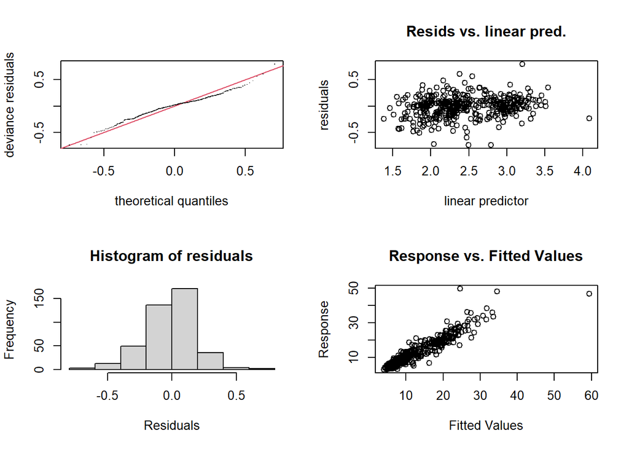

```
##
## Method: fREML   Optimizer: perf newton
## full convergence after 6 iterations.
## Gradient range [-7.196377e-11,3.356604e-11]
## (score 127.2543 & scale 0.05743722).
## Hessian positive definite, eigenvalue range [5.065605,210.9948].
## Model rank =  338 / 338
##
## Basis dimension (k) checking results. Low p-value (k-index<1) may
## indicate that k is too low, especially if edf is close to k'.
##
##                          k'   edf k-index p-value
## s(subj)                47.0  25.9      NA      NA
## s(subj,interval_type) 141.0  45.8      NA      NA
## s(subj,cluster)       141.0  62.2      NA      NA
```

```r
gam.check(ex5REML)
```

Model criticism, trimming:

```r
df3 <- df[abs(scale(resid(ex5REML))) < 2.5, ] # trim model
(1 - (nrow(df3))/nrow(df)) * 100
```

```
## [1] 2.173913
```

2.2% data removed.

Refit:

```r
summary(ex5REML_trim <- bam(RSD ~   interval_type*cluster + s(subj, bs='re') +  s(subj, cluster, bs='re')+  s(subj, interval_type, bs='re') , data=df3, family =Gamma(link=log)))
```

```
##
## Family: Gamma
## Link function: log
##
## Formula:
## RSD ~ interval_type * cluster + s(subj, bs = "re") + s(subj,
##     cluster, bs = "re") + s(subj, interval_type, bs = "re")
##
## Parametric coefficients:
##                                   Estimate Std. Error t value Pr(>|t|)
## (Intercept)                        2.31495    0.04759  48.640  < 2e-16 ***
## interval_typeleft edge             0.68745    0.04972  13.827  < 2e-16 ***
## interval_typeright edge           -0.48903    0.05003  -9.775  < 2e-16 ***
## clustersm                          0.07398    0.05343   1.385  0.16744
## clustersx                          0.06922    0.05457   1.268  0.20591
## interval_typeleft edge:clustersm   0.06568    0.05790   1.134  0.25772
## interval_typeright edge:clustersm  0.07514    0.05819   1.291  0.19780
## interval_typeleft edge:clustersx  -0.14194    0.05914  -2.400  0.01715 *
## interval_typeright edge:clustersx  0.23325    0.06056   3.851  0.00015 ***
## ---
## Signif. codes:  0 '***' 0.001 '**' 0.01 '*' 0.05 '.' 0.1 ' ' 1
##
## Approximate significance of smooth terms:
##                         edf Ref.df      F  p-value
## s(subj)               22.85     46 10.055 0.001330 **
## s(subj,cluster)       70.92    135  2.506 0.000321 ***
## s(subj,interval_type) 60.29    138  1.499 0.000889 ***
## ---
## Signif. codes:  0 '***' 0.001 '**' 0.01 '*' 0.05 '.' 0.1 ' ' 1
##
## R-sq.(adj) =  0.876   Deviance explained = 92.2%
## fREML =  77.52  Scale est. = 0.039043  n = 405
```

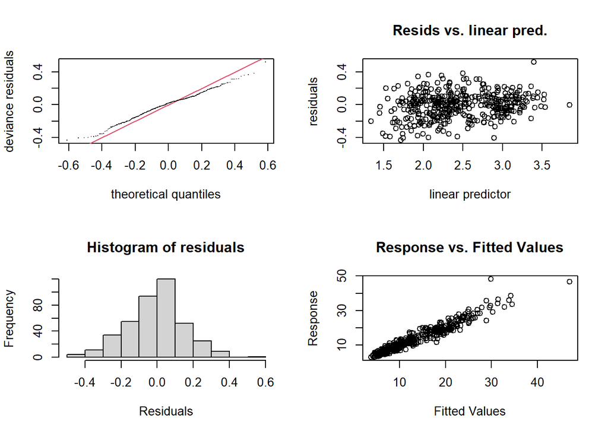

```
##
## Method: fREML   Optimizer: perf newton
## full convergence after 6 iterations.
## Gradient range [-1.004356e-07,4.947935e-08]
## (score 77.52038 & scale 0.03904272).
## Hessian positive definite, eigenvalue range [4.729307,210.1018].
## Model rank =  338 / 338
##
## Basis dimension (k) checking results. Low p-value (k-index<1) may
## indicate that k is too low, especially if edf is close to k'.
##
##                          k'   edf k-index p-value
## s(subj)                47.0  22.8      NA      NA
## s(subj,cluster)       141.0  70.9      NA      NA
## s(subj,interval_type) 141.0  60.3      NA      NA
```

```r
gam.check(ex5REML_trim)
```

Same pattern.

Visualize:

```
## Summary:
##  * interval_type : factor; set to the value(s): C-center, left edge, right edge. (Might be canceled as random effect, check below.)
##  * cluster : factor; set to the value(s): sp. (Might be canceled as random effect, check below.)
##  * subj : factor; set to the value(s): CTRL01. (Might be canceled as random effect, check below.)
##  * NOTE : The following random effects columns are canceled: s(subj),s(subj,cluster),s(subj,interval_type)
##
```

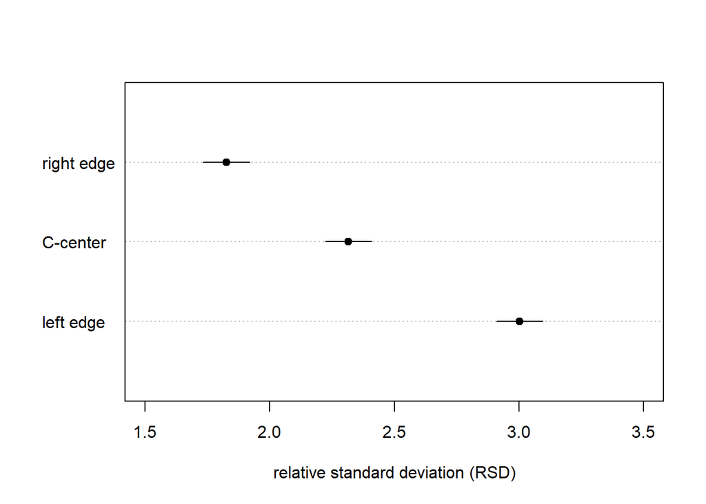

```r
plot_parametric(ex5REML_trim, cond = list(cluster = "sp"), pred=list(interval_type = c("left edge", "C-center", "right edge")), main = "", xlab = "relative standard deviation (RSD)", xlim=c(1.5,3.5))
```

```
## Summary:
##  * interval_type : factor; set to the value(s): C-center, left edge, right edge. (Might be canceled as random effect, check below.)
##  * cluster : factor; set to the value(s): sm. (Might be canceled as random effect, check below.)
##  * subj : factor; set to the value(s): CTRL01. (Might be canceled as random effect, check below.)
##  * NOTE : The following random effects columns are canceled: s(subj),s(subj,cluster),s(subj,interval_type)
##
```

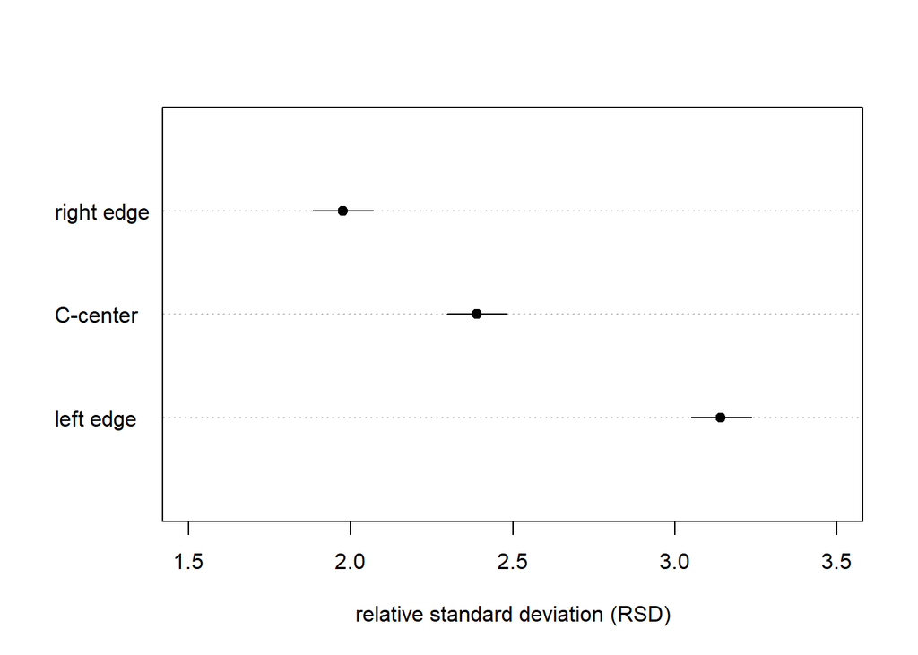

```r
plot_parametric(ex5REML_trim, cond = list(cluster = "sm"), pred=list(interval_type = c("left edge", "C-center", "right edge")), main = "", xlab = "relative standard deviation (RSD)", xlim=c(1.5,3.5))
```

```
## Summary:
##  * interval_type : factor; set to the value(s): C-center, left edge, right edge. (Might be canceled as random effect, check below.)
##  * cluster : factor; set to the value(s): sx. (Might be canceled as random effect, check below.)
##  * subj : factor; set to the value(s): CTRL01. (Might be canceled as random effect, check below.)
##  * NOTE : The following random effects columns are canceled: s(subj),s(subj,cluster),s(subj,interval_type)
##
```

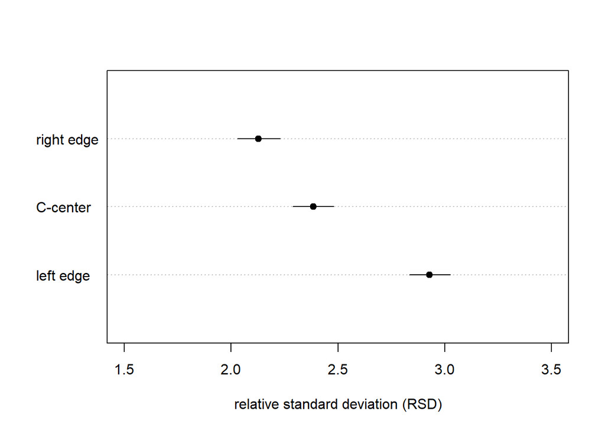

```r
plot_parametric(ex5REML_trim, cond = list(cluster = "sx"), pred=list(interval_type = c("left edge", "C-center", "right edge")), main = "", xlab = "relative standard deviation (RSD)", xlim=c(1.5,3.5))
```

# 3 Latex table

Latex table function:

```r
gamtabs2 <- function (model, caption = " ", label = "tab.gam",
    pnames = NA, snames = NA, ptab = NA, stab = NA, ...)
{
    if (!requireNamespace("xtable", quietly = TRUE)) {
        stop("Package 'xtable' needed for this function to work. Please install it.",
            call. = FALSE)
    }
    sum.gam <- model
    if (!inherits(model, "summary.gam")) {
        sum.gam <- summary(model)
    }
    if (is.na(ptab[1])) {
        ptab = as.data.frame(sum.gam$p.table, stringsAsFactors = FALSE)
    }
    if (is.na(stab[1])) {
        stab = as.data.frame(sum.gam$s.table, stringsAsFactors = FALSE)
    }
    if (!is.na(pnames[1])) {
        rownames(ptab) = pnames
    }
    if (!is.na(snames[1])) {
        rownames(stab) = snames
    }
    colnames(ptab)[4] = "p-value"
    colnames(ptab)[3] = "t-value"
    ptab.cnames = colnames(ptab)
    stab.cnames = colnames(stab)
    stab.cnames[3] = "F-value"
    colnames(ptab) = c("A", "B", "C", "D")
    if (ncol(stab) != 0) {
        colnames(stab) = colnames(ptab)
    }
    tab = rbind(ptab, stab)
    colnames(tab) = ptab.cnames
    tab = round(tab, 4)
    m = data.frame(matrix(0, nrow(tab), ncol(tab)), stringsAsFactors = FALSE)
    for (i in 1:nrow(tab)) {
        for (j in 1:4) {
            if ((j == 4) & (tab[i, j] < 1e-03)) {
                m[i, j] = "< 0.001"
            }
            else {
                m[i, j] = sprintf("%3.3f", tab[i, j])
            }
        }
    }
    colnames(m) = colnames(tab)
    rownames(m) = rownames(tab)
    tab = m
    tab2 = rbind(c(ptab.cnames), tab[1:nrow(ptab), ])
    if (nrow(stab) > 0) {
        tab2 = rbind(tab2, c(stab.cnames), tab[(nrow(ptab) +
            1):nrow(tab), ])
    }
    if (nrow(stab)) {
        rownames(tab2)[(nrow(ptab) + 2)] = "B. smooth terms"
    }
    rownames(tab2)[1] = "A. parametric coefficients"
    for (i in 1:nrow(tab2)) {
        if (tab2[i, 4] == "0")
            tab2[i, 4] = "< 0.0001"
        if (length(grep("\\.", tab2[i, 2])) == 0)
            tab2[i, 2] = paste(tab2[i, 2], ".0000", sep = "")
    }
    print(xtable::xtable(tab2, caption = caption, label = label,
        align = "lrrrr"), include.colnames = FALSE, hline.after = c(0,
        (nrow(ptab) + 1), nrow(tab2)), ...)
}
```

Latex table:

```r
options(xtable.comment = FALSE)
gamtabs2(ex5REML_trim)
```

```
## \begin{table}[ht]
## \centering
## \begin{tabular}{lrrrr}
##    \hline
## A. parametric coefficients & Estimate & Std. Error & t-value & p-value \\
##   (Intercept) & 2.315 & 0.048 & 48.639 & $<$ 0.001 \\
##   interval\_typeleft edge & 0.688 & 0.050 & 13.827 & $<$ 0.001 \\
##   interval\_typeright edge & -0.489 & 0.050 & -9.775 & $<$ 0.001 \\
##   clustersm & 0.074 & 0.053 & 1.385 & 0.167 \\
##   clustersx & 0.069 & 0.055 & 1.268 & 0.206 \\
##   interval\_typeleft edge:clustersm & 0.066 & 0.058 & 1.135 & 0.258 \\
##   interval\_typeright edge:clustersm & 0.075 & 0.058 & 1.291 & 0.198 \\
##   interval\_typeleft edge:clustersx & -0.142 & 0.059 & -2.400 & 0.017 \\
##   interval\_typeright edge:clustersx & 0.233 & 0.061 & 3.851 & $<$ 0.001 \\
##    \hline
## B. smooth terms & edf & Ref.df & F-value & p-value \\
##   s(subj) & 22.846 & 46.000 & 10.055 & 0.001 \\
##   s(subj,cluster) & 70.917 & 135.000 & 2.506 & $<$ 0.001 \\
##   s(subj,interval\_type) & 60.289 & 138.000 & 1.499 & $<$ 0.001 \\
##    \hline
## \end{tabular}
## \caption{ }
## \label{tab.gam}
## \end{table}
```